# Poblaciones Estructuradas: Análisis con Matrices Demográficas

Ecología de Poblaciones — Curso de Postgrado

2026-04-25

## Objetivos de aprendizaje

Al finalizar este taller, el estudiante será capaz de:

1. Construir una **matriz de Leslie** (estructurada por edad) y una **matriz de Lefkovitch** (estructurada por etapa) a partir de datos demográficos.
2. Calcular e interpretar los parámetros demográficos fundamentales: $R_0$, $T$, $r$ y $\lambda$.
3. Realizar **proyecciones poblacionales** y visualizar la dinámica de cada clase o etapa.
4. Ejecutar un **eigenanálisis completo**: tasa finita de crecimiento ($\lambda_1$), distribución estable ($\mathbf{w}$), valor reproductivo ($\mathbf{v}$) y ratio de amortiguamiento ($\rho$).
5. Interpretar los análisis de **sensibilidad y elasticidad** en el contexto del manejo y la conservación.
6. Aplicar un **LTRE** (*Life Table Response Experiment*) para descomponer diferencias en $\lambda$ entre poblaciones.

> **Instrucción:** Todos los archivos de datos deben estar en la **misma carpeta** que este script. No es necesario definir `setwd()`.

# Paquetes

```r
packages <- c("ggplot2", "popdemo", "readr", "dplyr", "tidyr",
              "igraph", "Rage", "readxl", "knitr")

installed_packages <- packages %in% rownames(installed.packages())
if (any(!installed_packages)) {
  install.packages(packages[!installed_packages])
}

library(popdemo)
library(readr)
library(dplyr)
library(tidyr)
library(ggplot2)
library(igraph)
library(Rage)
library(readxl)
library(knitr)
library(Rage)
```

# Fundamentos: Tablas de vida

## Estructura de la tabla de vida

Una **tabla de vida** registra la supervivencia y reproducción de una cohorte a lo largo del tiempo. Sus columnas principales son:

| Columna | Definición |
| --- | --- |
| $x$ | Clase de edad (años) |
| $N$ | Número de individuos al inicio del intervalo $x$ |
| $l_x$ | Probabilidad de sobrevivir desde el nacimiento hasta la edad $x$ ($l_0 = 1$) |
| $m_x$ | Número promedio de crías por hembra en la clase de edad $x$ |

```r
life_table <- read_csv("Life_tab_2.csv", show_col_types = FALSE)
kable(life_table, caption = "Tabla de vida de ejemplo (especie hipotética, 8 clases de edad)")
```

Tabla de vida de ejemplo (especie hipotética, 8 clases de edad)

| x | N | lx | mx |
| --- | --- | --- | --- |
| 0 | 100 | 1.00 | 0 |
| 1 | 25 | 0.25 | 0 |
| 2 | 12 | 0.12 | 2 |
| 3 | 9 | 0.09 | 5 |
| 4 | 6 | 0.06 | 5 |
| 5 | 4 | 0.04 | 5 |
| 6 | 3 | 0.03 | 2 |
| 7 | 2 | 0.02 | 2 |
| 8 | 0 | 0.00 | 0 |

## Parámetros demográficos: $R_0$, $T$ y $r$

A partir de la tabla de vida calculamos tres parámetros clave:

| Parámetro | Fórmula | Interpretación |
| --- | --- | --- |
| $R_0 = \sum l_x m_x$ | Tasa neta de reproducción | Número de hijas por hembra a lo largo de su vida |
| $T = \frac{\sum x \cdot l_x m_x}{R_0}$ | Tiempo generacional | Tiempo promedio entre generaciones |
| $r \approx \frac{\ln R_0}{T}$ | Tasa intrínseca de incremento | Tasa de crecimiento instantánea (continua) |

```r
R0_val <- sum(life_table$lx * life_table$mx)
T_val  <- sum(life_table$x * life_table$lx * life_table$mx) / R0_val
r_val  <- log(R0_val) / T_val

life_table <- life_table %>%
  mutate(
    lx_mx   = lx * mx,
    x_lx_mx = x  * lx * mx
  )

kable(
  life_table %>% select(x, N, lx, mx, lx_mx, x_lx_mx),
  digits  = 4,
  caption = "Tabla de vida con columnas auxiliares para el cálculo de parámetros"
)
```

Tabla de vida con columnas auxiliares para el cálculo de parámetros

| x | N | lx | mx | lx_mx | x_lx_mx |
| --- | --- | --- | --- | --- | --- |
| 0 | 100 | 1.00 | 0 | 0.00 | 0.00 |
| 1 | 25 | 0.25 | 0 | 0.00 | 0.00 |
| 2 | 12 | 0.12 | 2 | 0.24 | 0.48 |
| 3 | 9 | 0.09 | 5 | 0.45 | 1.35 |
| 4 | 6 | 0.06 | 5 | 0.30 | 1.20 |
| 5 | 4 | 0.04 | 5 | 0.20 | 1.00 |
| 6 | 3 | 0.03 | 2 | 0.06 | 0.36 |
| 7 | 2 | 0.02 | 2 | 0.04 | 0.28 |
| 8 | 0 | 0.00 | 0 | 0.00 | 0.00 |

```r
cat("R0 =", round(R0_val, 4), "\n")
```

```
## R0 = 1.29
```

```r
cat("T  =", round(T_val,  4), "anos\n")
```

```
## T  = 3.6202 anos
```

```r
cat("r  =", round(r_val,  4), "por ano\n")
```

```
## r  = 0.0703 por ano
```

## Relación entre $R_0$, $r$ y $\lambda$

Los tres parámetros miden el mismo fenómeno a distintas escalas temporales y están relacionados matemáticamente:

$$\lambda = e^r \qquad \Longleftrightarrow
\qquad r = \ln \lambda \qquad \Longleftrightarrow \qquad R_0 \approx
\lambda^T$$

```r
lambda_desde_r <- exp(r_val)
R0_desde_lambda <- lambda_desde_r ^ T_val

cat("lambda estimada desde r:  e^r =", round(lambda_desde_r, 4), "\n")
```

```
## lambda estimada desde r:  e^r = 1.0729
```

```r
cat("R0 desde lambda y T: lambda^T =", round(R0_desde_lambda, 4),
    " | R0 observado =", round(R0_val, 4), "\n")
```

```
## R0 desde lambda y T: lambda^T = 1.29  | R0 observado = 1.29
```

> **Interpretación:**
> - $\lambda > 1$ ($r > 0$, $R_0 > 1$): población en **crecimiento**.
> - $\lambda = 1$ ($r = 0$, $R_0 = 1$): población **estable**.
> - $\lambda < 1$ ($r < 0$, $R_0 < 1$): población en **declinación**.

## Curva de supervivencia

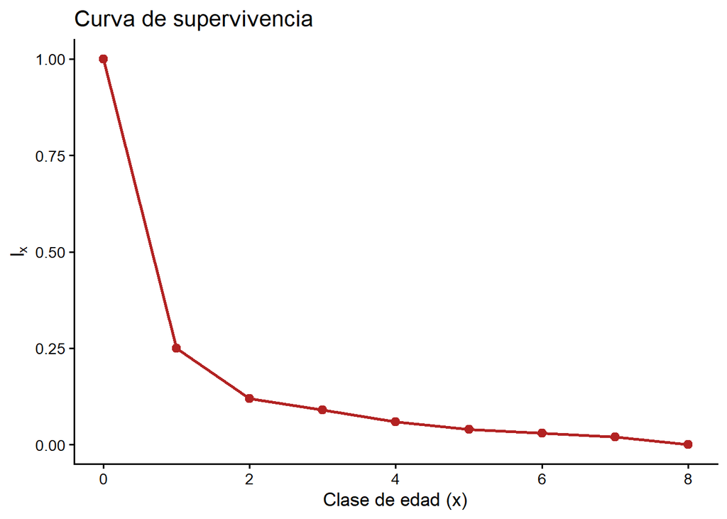

Curva de supervivencia. Cada punto representa la probabilidad acumulada de sobrevivir hasta esa clase de edad.

```r
ggplot(life_table, aes(x = x, y = lx)) +
  geom_line(color = "firebrick", linewidth = 1) +
  geom_point(color = "firebrick", size = 2.5) +
  scale_y_continuous(limits = c(0, 1)) +
  labs(
    title = "Curva de supervivencia",
    x     = "Clase de edad (x)",
    y     = expression(l[x])
  ) +
  theme_classic(base_size = 13)
```

# Matriz de Leslie (estructurada por edad)

## Estructura y fundamentos teóricos

La **matriz de Leslie** $\mathbf{A}$ describe la dinámica de una población estructurada por edad bajo el modelo de nacimiento pulsado con censo *post*-nacimiento. Sus elementos son:

- **Fila 1** — Fertilidades: $F_i = G_i \cdot m_{i+1}$
- **Subdiagonal** — Supervivencias: $G_i = l_{i+1} / l_i$

donde $G_i$ es la probabilidad de que un individuo en la clase $i$ sobreviva y pase a la clase $i+1$.

$$\mathbf{A} = \begin{pmatrix} F_1 &
F_2 & \cdots & F_n \\ G_1 & 0 & \cdots & 0 \\ 0
& G_2 & \cdots & 0 \\ \vdots & & \ddots & \vdots
\\ 0 & 0 & G_{n-1} & 0 \end{pmatrix}$$

## Cálculo de $G_i$ y $F_i$

```r
n  <- nrow(life_table)
lx <- life_table$lx
mx <- life_table$mx

Gi <- lx[2:n] / lx[1:(n - 1)]   # probabilidades de supervivencia por clase
Fi <- Gi * mx[2:n]               # fertilidades

kable(
  data.frame(Clase = seq_len(n - 1), Gi = round(Gi, 4), Fi = round(Fi, 4)),
  caption = "Probabilidades de supervivencia (Gi) y fertilidades (Fi) por clase de edad"
)
```

Probabilidades de supervivencia (Gi) y fertilidades (Fi) por clase de edad

| Clase | Gi | Fi |
| --- | --- | --- |
| 1 | 0.2500 | 0.0000 |
| 2 | 0.4800 | 0.9600 |
| 3 | 0.7500 | 3.7500 |
| 4 | 0.6667 | 3.3333 |
| 5 | 0.6667 | 3.3333 |
| 6 | 0.7500 | 1.5000 |
| 7 | 0.6667 | 1.3333 |
| 8 | 0.0000 | 0.0000 |

## Construcción de la matriz

La función `leslie_from_table()` construye la matriz de Leslie a partir de cualquier vector $G_i$ y $F_i$:

```r
leslie_from_table <- function(Gi, Fi) {
  n <- length(Gi)
  A <- matrix(0, nrow = n, ncol = n)
  A[1, ] <- Fi
  for (i in seq_len(n - 1)) A[i + 1, i] <- Gi[i]
  A
}

A <- leslie_from_table(Gi, Fi)

kable(round(A, 4), caption = "Matriz de Leslie (A)")
```

Matriz de Leslie (A)

| 0.00 | 0.96 | 3.75 | 3.3333 | 3.3333 | 1.50 | 1.3333 | 0 |
| --- | --- | --- | --- | --- | --- | --- | --- |
| 0.25 | 0.00 | 0.00 | 0.0000 | 0.0000 | 0.00 | 0.0000 | 0 |
| 0.00 | 0.48 | 0.00 | 0.0000 | 0.0000 | 0.00 | 0.0000 | 0 |
| 0.00 | 0.00 | 0.75 | 0.0000 | 0.0000 | 0.00 | 0.0000 | 0 |
| 0.00 | 0.00 | 0.00 | 0.6667 | 0.0000 | 0.00 | 0.0000 | 0 |
| 0.00 | 0.00 | 0.00 | 0.0000 | 0.6667 | 0.00 | 0.0000 | 0 |
| 0.00 | 0.00 | 0.00 | 0.0000 | 0.0000 | 0.75 | 0.0000 | 0 |
| 0.00 | 0.00 | 0.00 | 0.0000 | 0.0000 | 0.00 | 0.6667 | 0 |

## Grafo del ciclo de vida

El grafo del ciclo de vida permite visualizar las transiciones posibles y sus magnitudes. En una matriz de Leslie, cada clase solo puede avanzar a la siguiente (subdiagonal) o contribuir con crías a la clase 1 (primera fila).

```r
plot_life_cycle(A, shape = "circle", edgecol = "firebrick")
```

[interactive chart not shown]

Grafo del ciclo de vida de la Matriz de Leslie.

# Proyecciones poblacionales

## Función de proyección

Encapsulamos la proyección en una función reutilizable para cualquier matriz y horizonte temporal:

```r
proyectar <- function(A, N0, anos) {
  n <- nrow(A)
  N <- matrix(0, nrow = n, ncol = anos + 1)
  N[, 1] <- N0
  for (t in seq_len(anos)) N[, t + 1] <- A %*% N[, t]
  N
}
```

## Proyección multianual por clase de edad

Partimos del vector de abundancias inicial $\mathbf{N}_0$ registrado en la tabla de vida:

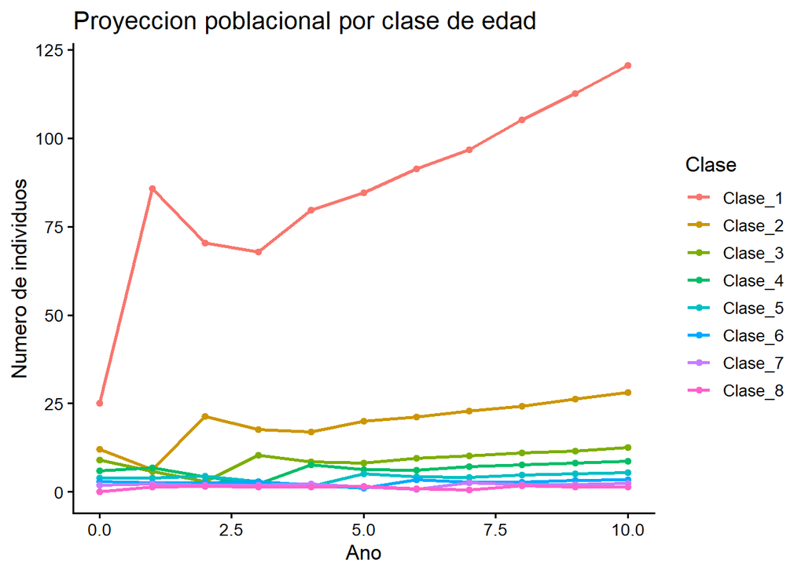

Abundancia de cada clase de edad a lo largo de 10 años de proyección.

```r
N0    <- as.numeric(life_table$N[-1])   # excluye la fila de edad 0
years <- 10

N_proj <- proyectar(A, N0, years)

N_df <- as.data.frame(t(N_proj))
colnames(N_df) <- paste0("Clase_", seq_len(nrow(A)))
N_df$Ano <- 0:years

pivot_longer(N_df, cols = -Ano, names_to = "Clase", values_to = "N") %>%
  ggplot(aes(x = Ano, y = N, color = Clase)) +
  geom_line(linewidth = 0.9) +
  geom_point(size = 1.5) +
  labs(
    title = "Proyeccion poblacional por clase de edad",
    x     = "Ano",
    y     = "Numero de individuos"
  ) +
  theme_classic(base_size = 13)
```

## Distribución estable de edades

Al proyectar durante suficientes años, la **proporción** de individuos en cada clase converge a una distribución constante: la **distribución estable de edades**.

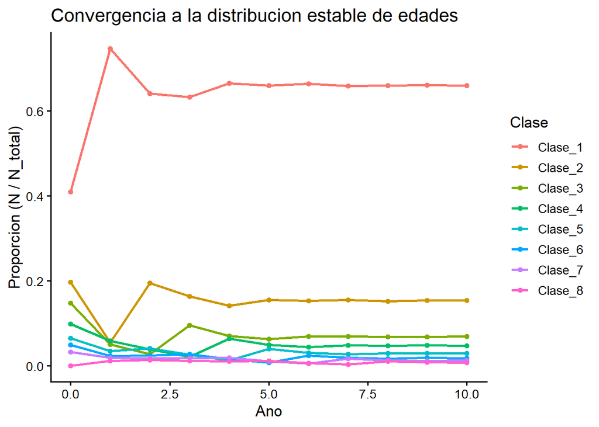

Convergencia a la distribución estable de edades. Las proporciones se estabilizan con el tiempo.

```r
N_totals <- colSums(N_proj)
N_prop   <- sweep(N_proj, 2, N_totals, "/")

N_prop_df <- as.data.frame(t(N_prop))
colnames(N_prop_df) <- paste0("Clase_", seq_len(nrow(A)))
N_prop_df$Ano <- 0:years

pivot_longer(N_prop_df, cols = -Ano, names_to = "Clase", values_to = "Proporcion") %>%
  ggplot(aes(x = Ano, y = Proporcion, color = Clase)) +
  geom_line(linewidth = 0.9) +
  geom_point(size = 1.5) +
  labs(
    title = "Convergencia a la distribucion estable de edades",
    x     = "Ano",
    y     = "Proporcion (N / N_total)"
  ) +
  theme_classic(base_size = 13)
```

# Eigenanálisis

El **eigenanálisis** (análisis espectral) de $\mathbf{A}$ entrega los descriptores asintóticos fundamentales de la dinámica poblacional.

## Tasa finita de crecimiento ($\lambda_1$)

El **eigenvalor dominante** $\lambda_1$ es la tasa finita de crecimiento de la población en el estado estable.

```r
eigs_A  <- eigen(A)
dom_pos <- which.max(Re(eigs_A$values))
lambda1 <- Re(eigs_A$values[dom_pos])

cat("Eigenvalores de A (parte real):\n")
```

```
## Eigenvalores de A (parte real):
```

```r
print(round(Re(eigs_A$values), 6))
```

```
## [1]  1.074035 -0.537780 -0.537780 -0.157591 -0.157591  0.158354  0.158354
## [8]  0.000000
```

```r
cat("\nlambda1 (tasa finita de crecimiento) =", round(lambda1, 6))
```

```
##
## lambda1 (tasa finita de crecimiento) = 1.074035
```

```r
cat("\nEquivalente a r = ln(lambda1)        =", round(log(lambda1), 6), "por ano\n")
```

```
##
## Equivalente a r = ln(lambda1)        = 0.071423 por ano
```

> La población hipotética **crece** a una tasa de 7.4% por año ($\lambda_1 =$ 1.074).

## Distribución estable de edades ($\mathbf{w}$)

El **eigenvector derecho** $\mathbf{w}$ (normalizado para que sus elementos sumen 1) da la proporción de individuos en cada clase al estado estable. Es el mismo patrón que converge en la sección anterior.

```r
w      <- Re(eigs_A$vectors[, dom_pos])
w_norm <- w / sum(w)

w_df <- data.frame(
  Clase      = paste0("Clase_", seq_along(w_norm)),
  Proporcion = round(w_norm, 4)
)

kable(w_df, caption = "Distribucion estable de edades (w normalizado, suma = 1)")
```

Distribucion estable de edades (w normalizado, suma = 1)

| Clase | Proporcion |
| --- | --- |
| Clase_1 | 0.6604 |
| Clase_2 | 0.1537 |
| Clase_3 | 0.0687 |
| Clase_4 | 0.0480 |
| Clase_5 | 0.0298 |
| Clase_6 | 0.0185 |
| Clase_7 | 0.0129 |
| Clase_8 | 0.0080 |

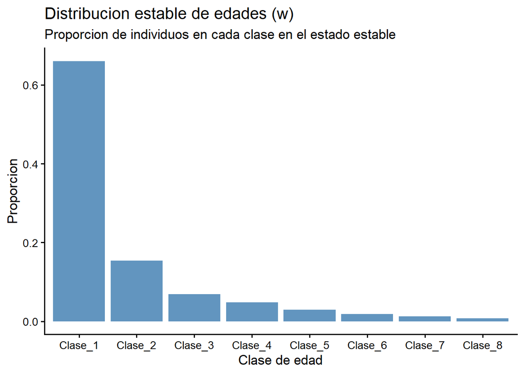

Distribución estable de edades (w). Proporción esperada de individuos en cada clase en el largo plazo.

```r
ggplot(w_df, aes(x = Clase, y = Proporcion)) +
  geom_col(fill = "steelblue", alpha = 0.85) +
  labs(
    title    = "Distribucion estable de edades (w)",
    subtitle = "Proporcion de individuos en cada clase en el estado estable",
    x        = "Clase de edad",
    y        = "Proporcion"
  ) +
  theme_classic(base_size = 13)
```

## Valor reproductivo ($\mathbf{v}$)

El **eigenvector izquierdo** $\mathbf{v}$ mide el **valor reproductivo** de cada clase: la contribución esperada de un individuo de esa clase al crecimiento futuro de la población, relativa a la clase 1. Es un descriptor esencial para la planificación del manejo y la conservación.

```r
eigs_left  <- eigen(t(A))
dom_pos_l  <- which.max(Re(eigs_left$values))
v          <- Re(eigs_left$vectors[, dom_pos_l])
v_norm     <- v / v[1]   # normalizar relativo a la clase 1

v_df <- data.frame(
  Clase             = paste0("Clase_", seq_along(v_norm)),
  ValorReproductivo = round(v_norm, 4)
)

kable(v_df, caption = "Valor reproductivo relativo (v normalizado: Clase 1 = 1)")
```

Valor reproductivo relativo (v normalizado: Clase 1 = 1)

| Clase | ValorReproductivo |
| --- | --- |
| Clase_1 | 1.0000 |
| Clase_2 | 4.2961 |
| Clase_3 | 7.6129 |
| Clase_4 | 5.9021 |
| Clase_5 | 4.5085 |
| Clase_6 | 2.2635 |
| Clase_7 | 1.2414 |
| Clase_8 | 0.0000 |

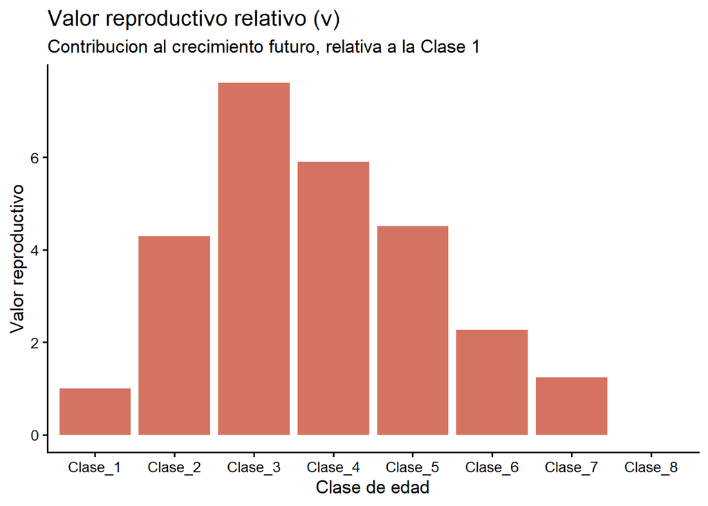

Valor reproductivo relativo (v). Indica el ‘peso’ de cada individuo en la dinámica futura de la población.

```r
ggplot(v_df, aes(x = Clase, y = ValorReproductivo)) +
  geom_col(fill = "coral3", alpha = 0.85) +
  labs(
    title    = "Valor reproductivo relativo (v)",
    subtitle = "Contribucion al crecimiento futuro, relativa a la Clase 1",
    x        = "Clase de edad",
    y        = "Valor reproductivo"
  ) +
  theme_classic(base_size = 13)
```

> **Interpretación:** Un individuo en la Clase 3 tiene un valor reproductivo 7.6 veces mayor que uno en la Clase 1 (recién nacido). Eliminar individuos de las clases con mayor valor reproductivo tiene un impacto desproporcionado sobre el crecimiento poblacional.

## Ratio de amortiguamiento ($\rho$)

El **ratio de amortiguamiento** mide qué tan rápido converge la población a su distribución estable de edades tras una perturbación:

$$\rho =
\frac{\lambda_1}{|\lambda_2|}$$

Un $\rho$ alto implica convergencia rápida; un $\rho$ cercano a 1 implica transitorios prolongados y oscilaciones lentas en la estructura etaria.

```r
lambda2 <- sort(Mod(eigs_A$values), decreasing = TRUE)[2]
rho     <- lambda1 / lambda2

cat("lambda1 =", round(lambda1, 6), "\n")
```

```
## lambda1 = 1.074035
```

```r
cat("|lambda2| =", round(lambda2, 6), "\n")
```

```
## |lambda2| = 0.628912
```

```r
cat("rho = lambda1 / |lambda2| =", round(rho, 4), "\n")
```

```
## rho = lambda1 / |lambda2| = 1.7078
```

## Convergencia de $\lambda_t$ hacia $\lambda_1$

Podemos verificar empíricamente que la tasa de crecimiento anual $\lambda_t = N_{t+1}/N_t$ converge a $\lambda_1$ en proyecciones largas:

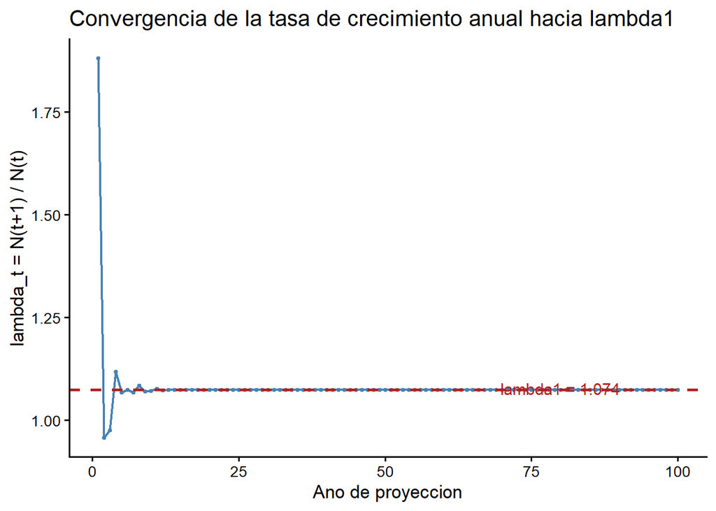

Convergencia de la tasa de crecimiento anual hacia el eigenvalor dominante (línea roja discontinua).

```r
years_conv <- 100
N_conv     <- proyectar(A, N0, years_conv)
N_tot_conv <- colSums(N_conv)
Rs_conv    <- N_tot_conv[-1] / N_tot_conv[-(years_conv + 1)]

ggplot(data.frame(Ano = seq_len(years_conv), Lambda_t = Rs_conv),
       aes(x = Ano, y = Lambda_t)) +
  geom_line(color = "steelblue", linewidth = 0.8) +
  geom_point(color = "steelblue", size = 0.8) +
  geom_hline(yintercept = lambda1, color = "firebrick",
             linetype = "dashed", linewidth = 1) +
  annotate("text", x = 80, y = lambda1 + 0.004,
           label = paste0("lambda1 = ", round(lambda1, 4)),
           color = "firebrick", size = 4) +
  labs(
    title = "Convergencia de la tasa de crecimiento anual hacia lambda1",
    x     = "Ano de proyeccion",
    y     = "lambda_t = N(t+1) / N(t)"
  ) +
  theme_classic(base_size = 13)
```

```r
cat("Valor de lambda en el ano 100:", round(Rs_conv[100], 6))
```

```
## Valor de lambda en el ano 100: 1.074035
```

# Sensibilidad y elasticidad

## Sensibilidad

La **sensibilidad** $s_{ij}$ mide cuánto cambiaría $\lambda_1$ ante un pequeño cambio *aditivo* en el elemento $a_{ij}$ de la matriz:

$$s_{ij} = \frac{\partial
\lambda_1}{\partial a_{ij}} = \frac{v_i \, w_j}{\langle \mathbf{v},
\mathbf{w} \rangle}$$

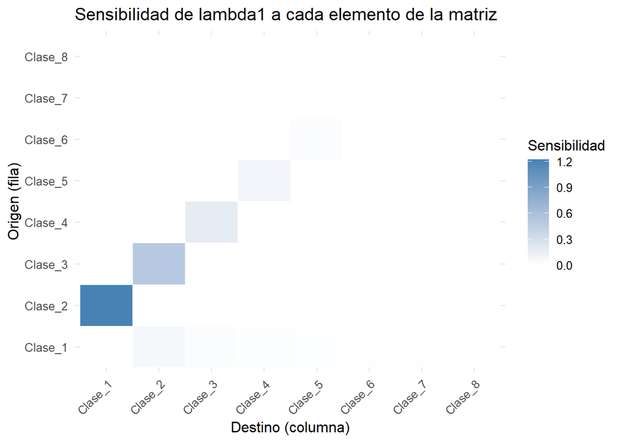

Mapa de calor de sensibilidad. Valores altos indican que pequeños cambios absolutos en esa transición tienen gran impacto sobre lambda.

```r
S <- sens(A, eval = "max")

as.data.frame(S) %>%
  setNames(paste0("Clase_", seq_len(ncol(S)))) %>%
  mutate(Origen = paste0("Clase_", seq_len(nrow(S)))) %>%
  pivot_longer(cols = -Origen, names_to = "Destino", values_to = "Sensibilidad") %>%
  ggplot(aes(x = Destino, y = Origen, fill = Sensibilidad)) +
  geom_tile(color = "white") +
  scale_fill_gradient(low = "white", high = "steelblue") +
  labs(
    title = "Sensibilidad de lambda1 a cada elemento de la matriz",
    x     = "Destino (columna)",
    y     = "Origen (fila)"
  ) +
  theme_minimal(base_size = 12) +
  theme(axis.text.x = element_text(angle = 45, hjust = 1))
```

## Elasticidad

La **elasticidad** $e_{ij}$ mide el cambio *proporcional* en $\lambda_1$ ante un cambio proporcional en $a_{ij}$:

$$e_{ij} = \frac{a_{ij}}{\lambda_1} \cdot
s_{ij} = \frac{\partial \ln \lambda_1}{\partial \ln a_{ij}}$$

Una propiedad clave: los elementos de elasticidad **siempre suman 1**, lo que permite interpretarlos como contribuciones porcentuales a $\lambda_1$.

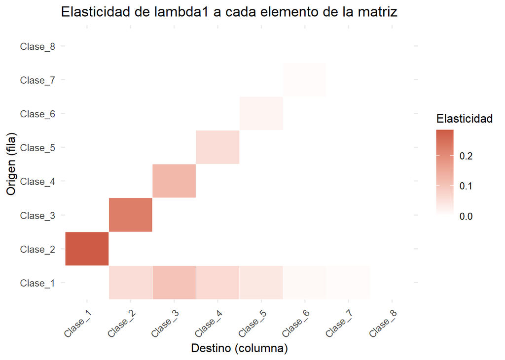

Mapa de calor de elasticidad. Los valores suman 1 y representan la contribución proporcional de cada transición a lambda.

```r
E <- elas(A, eval = "max")

as.data.frame(E) %>%
  setNames(paste0("Clase_", seq_len(ncol(E)))) %>%
  mutate(Origen = paste0("Clase_", seq_len(nrow(E)))) %>%
  pivot_longer(cols = -Origen, names_to = "Destino", values_to = "Elasticidad") %>%
  ggplot(aes(x = Destino, y = Origen, fill = Elasticidad)) +
  geom_tile(color = "white") +
  scale_fill_gradient(low = "white", high = "coral3") +
  labs(
    title = "Elasticidad de lambda1 a cada elemento de la matriz",
    x     = "Destino (columna)",
    y     = "Origen (fila)"
  ) +
  theme_minimal(base_size = 12) +
  theme(axis.text.x = element_text(angle = 45, hjust = 1))
```

```r
cat("Suma de elasticidades:", round(sum(E), 6), "(debe ser = 1)\n")
```

```
## Suma de elasticidades: 1 (debe ser = 1)
```

## Sensibilidad vs. elasticidad: diferencias clave

|  | Sensibilidad ($s_{ij}$) | Elasticidad ($e_{ij}$) |
| --- | --- | --- |
| **Escala** | Absoluta | Proporcional (%) |
| **Suma** | No restringida | Siempre = 1 |
| **Útil para** | Cambios absolutos en parámetros de unidades similares | Comparar parámetros de distintas magnitudes o escalas |
| **Aplicación en manejo** | ¿Cuánto cambia $\lambda$ si aumentamos $\sigma_1$ en 0.01? | ¿Qué fracción de $\lambda$ depende de la supervivencia de adultos? |

> **Para el manejo y la conservación:** las elasticidades permiten identificar los parámetros vitales que más influyen en $\lambda_1$ de forma proporcional. Si la elasticidad de la supervivencia de adultos domina, los esfuerzos de conservación deberían focalizarse en proteger a los adultos reproductivos.

# Matrices de Lefkovitch (estructuradas por etapa)

## Diferencias conceptuales con la Matriz de Leslie

La **Matriz de Leslie** asume que conocemos la **edad exacta** de cada individuo y que cada clase solo puede avanzar a la siguiente. Sin embargo, para muchas especies —plantas, reptiles, peces— es más práctico y biológicamente más apropiado clasificar individuos por **etapa de desarrollo**.

La **Matriz de Lefkovitch** generaliza la de Leslie permitiendo:

1. **Permanencia en la misma etapa** ($P_{ii}$, diagonal principal): individuos que sobreviven pero no maduran ese año (e.g., un árbol que permanece en el estadio juvenil por varios años).
2. **Retrogresión** ($a_{ij}$ con $i < j$): aunque poco común, es posible modelar encogimiento o retroceso de estadio en plantas o animales.

$$\mathbf{B} = \begin{pmatrix} P_1 & 0
& F_3 \\ G_{12} & P_2 & 0 \\ 0 & G_{23} & P_3
\end{pmatrix}$$

La diferencia estructural clave respecto a Leslie es la presencia de elementos en la **diagonal principal**.

## Ejemplo: planta perenne con tres etapas

Consideramos una planta perenne con tres etapas de vida:

- **Plántula (P)**: primer año de vida, alta mortalidad.
- **Juvenil (J)**: planta establecida, no reproductiva; puede permanecer en esta etapa varios años.
- **Adulto (A)**: planta reproductiva que puede sobrevivir múltiples años en el mismo estadio.

```r
etapas <- c("Plantula", "Juvenil", "Adulto")

B <- matrix(
  c(0.000, 0.000, 4.500,
    0.250, 0.350, 0.000,
    0.000, 0.550, 0.750),
  nrow = 3, ncol = 3, byrow = TRUE,
  dimnames = list(etapas, etapas)
)

kable(round(B, 3), caption = "Matriz de Lefkovitch para planta perenne (3 etapas)")
```

Matriz de Lefkovitch para planta perenne (3 etapas)

|  | Plantula | Juvenil | Adulto |
| --- | --- | --- | --- |
| Plantula | 0.00 | 0.00 | 4.50 |
| Juvenil | 0.25 | 0.35 | 0.00 |
| Adulto | 0.00 | 0.55 | 0.75 |

> **Interpretación de los elementos:**
> - $B_{13} = 4.5$: cada adulto produce 4.5 plántulas viables por año (fecundidad).
> - $B_{21} = 0.25$: 25% de las plántulas maduran a juveniles ese año (75% mueren).
> - $B_{22} = 0.35$: 35% de los juveniles permanecen como juveniles (no maduran ese año).
> - $B_{32} = 0.55$: 55% de los juveniles maduran a adultos.
> - $B_{33} = 0.75$: 75% de los adultos sobreviven y permanecen como adultos.

## Análisis completo de la Matriz de Lefkovitch

```r
plot_life_cycle(B, shape = "circle", edgecol = "darkgreen")
```

[interactive chart not shown]

Grafo del ciclo de vida para la planta perenne. Nótese el lazo de permanencia en Juvenil y Adulto (inexistente en la Matriz de Leslie).

```r
eigs_B    <- eigen(B)
dom_B     <- which.max(Re(eigs_B$values))
lambda_B  <- Re(eigs_B$values[dom_B])

w_B       <- Re(eigs_B$vectors[, dom_B])
w_B_norm  <- w_B / sum(w_B)

eigs_B_l  <- eigen(t(B))
dom_B_l   <- which.max(Re(eigs_B_l$values))
v_B       <- Re(eigs_B_l$vectors[, dom_B_l])
v_B_norm  <- v_B / v_B[1]

lambda2_B <- sort(Mod(eigs_B$values), decreasing = TRUE)[2]
rho_B     <- lambda_B / lambda2_B

cat("lambda1 (planta perenne):", round(lambda_B, 4), "\n")
```

```
## lambda1 (planta perenne): 1.2748
```

```r
cat("r equivalente:           ", round(log(lambda_B), 4), "por ano\n")
```

```
## r equivalente:            0.2428 por ano
```

```r
cat("rho (amortiguamiento):   ", round(rho_B, 4), "\n\n")
```

```
## rho (amortiguamiento):    1.8298
```

```r
kable(
  data.frame(
    Etapa          = etapas,
    w_estable      = round(w_B_norm, 4),
    v_reproductivo = round(v_B_norm, 4)
  ),
  caption = "Distribucion estable de etapas (w) y valor reproductivo relativo (v)"
)
```

Distribucion estable de etapas (w) y valor reproductivo relativo (v)

| Etapa | w_estable | v_reproductivo |
| --- | --- | --- |
| Plantula | 0.6437 | 1.0000 |
| Juvenil | 0.1740 | 5.0993 |
| Adulto | 0.1823 | 8.5744 |

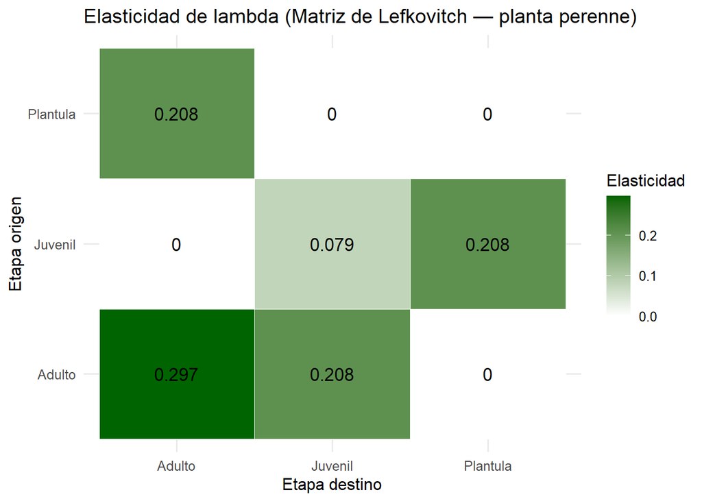

Elasticidades de la Matriz de Lefkovitch. En plantas perennes longevas, la supervivencia del adulto (B_33) suele dominar.

```r
E_B <- elas(B, eval = "max")

as.data.frame(E_B) %>%
  setNames(etapas) %>%
  mutate(Origen = etapas) %>%
  pivot_longer(cols = -Origen, names_to = "Destino", values_to = "Elasticidad") %>%
  ggplot(aes(x = Destino, y = Origen, fill = Elasticidad)) +
  geom_tile(color = "white") +
  geom_text(aes(label = round(Elasticidad, 3)), size = 4.5) +
  scale_fill_gradient(low = "white", high = "darkgreen") +
  labs(
    title = "Elasticidad de lambda (Matriz de Lefkovitch — planta perenne)",
    x     = "Etapa destino",
    y     = "Etapa origen"
  ) +
  theme_minimal(base_size = 12)
```

```r
cat("Suma de elasticidades:", round(sum(E_B), 6))
```

```
## Suma de elasticidades: 1
```

> **Interpretación:** En plantas longevas, la elasticidad del término de permanencia del adulto ($B_{33}$) suele ser la más alta. Esto significa que pequeñas mejoras en la supervivencia de adultos tienen el mayor retorno potencial para el crecimiento poblacional.

# Ejercicio: *Vulpes vulpes*

Se tienen dos matrices de proyección para el zorro rojo (*Vulpes vulpes*) en Australia, obtenidas de la base de datos **COMADRE** (Devenish-Nelson et al. 2013, *Oikos*). Ambas matrices tienen 4 clases de edad (0+, 1+, 2+, ≥3 años):

- `vulpes_haunt`: población bajo **caza intensiva**.
- `vulpes_unman`: población **sin intervención** (control).

> **Fuente:** Devenish-Nelson E.S. et al. (2013). Do life history traits predict population growth rates of hunted ungulates? *Oikos*, 122(4). COMADRE IDs: 249920 y 249921.

```r
clases_v <- c("0+", "1+", "2+", ">=3")

vulpes_haunt <- matrix(
  c(0.370, 0.610, 1.210, 1.580,
    0.300, 0.000, 0.000, 0.000,
    0.000, 0.350, 0.000, 0.000,
    0.000, 0.000, 0.570, 0.700),
  nrow = 4, ncol = 4, byrow = TRUE,
  dimnames = list(clases_v, clases_v)
)

vulpes_unman <- matrix(
  c(0.686, 1.271, 1.426, 0.332,
    0.390, 0.000, 0.000, 0.000,
    0.000, 0.650, 0.000, 0.000,
    0.000, 0.000, 0.920, 0.180),
  nrow = 4, ncol = 4, byrow = TRUE,
  dimnames = list(clases_v, clases_v)
)

kable(vulpes_haunt, digits = 3, caption = "Vulpes vulpes — poblacion bajo caza intensiva")
```

Vulpes vulpes — poblacion bajo caza intensiva

|  | 0+ | 1+ | 2+ | >=3 |
| --- | --- | --- | --- | --- |
| 0+ | 0.37 | 0.61 | 1.21 | 1.58 |
| 1+ | 0.30 | 0.00 | 0.00 | 0.00 |
| 2+ | 0.00 | 0.35 | 0.00 | 0.00 |
| >=3 | 0.00 | 0.00 | 0.57 | 0.70 |

```r
kable(vulpes_unman, digits = 3, caption = "Vulpes vulpes — poblacion control (sin caza)")
```

Vulpes vulpes — poblacion control (sin caza)

|  | 0+ | 1+ | 2+ | >=3 |
| --- | --- | --- | --- | --- |
| 0+ | 0.686 | 1.271 | 1.426 | 0.332 |
| 1+ | 0.390 | 0.000 | 0.000 | 0.000 |
| 2+ | 0.000 | 0.650 | 0.000 | 0.000 |
| >=3 | 0.000 | 0.000 | 0.920 | 0.180 |

## Preguntas guía

### 1. Grafique el ciclo de vida de cada población

```r
par(mfrow = c(1, 2))
plot_life_cycle(vulpes_haunt, shape = "circle", edgecol = "firebrick",
                title = "Caza intensa")
```

[interactive chart not shown]

```r
plot_life_cycle(vulpes_unman, shape = "circle", edgecol = "steelblue",
                title = "Control")
```

[interactive chart not shown]

```r
par(mfrow = c(1, 1))
```

> **Analice:** ¿En qué difieren las topologías y las magnitudes de las transiciones entre las dos poblaciones?

### 2. Calcule $\lambda_1$, $r$, $\mathbf{w}$, $\mathbf{v}$ y $\rho$ para cada población

Usaremos una función auxiliar que encapsula el eigenanálisis completo:

```r
calc_eigen_completo <- function(mat) {
  eig   <- eigen(mat)
  dpos  <- which.max(Re(eig$values))
  lam   <- Re(eig$values[dpos])
  w_raw <- Re(eig$vectors[, dpos])
  eig_l <- eigen(t(mat))
  v_raw <- Re(eig_l$vectors[, which.max(Re(eig_l$values))])
  list(
    lambda = lam,
    w      = w_raw / sum(w_raw),
    v      = v_raw / v_raw[1],
    rho    = lam / sort(Mod(eig$values), decreasing = TRUE)[2]
  )
}

res_haunt <- calc_eigen_completo(vulpes_haunt)
res_unman <- calc_eigen_completo(vulpes_unman)

kable(
  data.frame(
    Parametro  = c("lambda1", "r", "rho"),
    Caza       = c(round(res_haunt$lambda, 4),
                   round(log(res_haunt$lambda), 4),
                   round(res_haunt$rho, 4)),
    Control    = c(round(res_unman$lambda, 4),
                   round(log(res_unman$lambda), 4),
                   round(res_unman$rho, 4))
  ),
  caption = "Comparacion de parametros demograficos entre las dos poblaciones"
)
```

Comparacion de parametros demograficos entre las dos poblaciones

| Parametro | Caza | Control |
| --- | --- | --- |
| lambda1 | 0.9985 | 1.3129 |
| r | -0.0015 | 0.2722 |
| rho | 5.1441 | 2.9707 |

```r
kable(
  data.frame(
    Clase   = clases_v,
    w_haunt = round(res_haunt$w, 4),
    w_unman = round(res_unman$w, 4),
    v_haunt = round(res_haunt$v, 4),
    v_unman = round(res_unman$v, 4)
  ),
  caption = "Distribucion estable (w) y valor reproductivo (v) por clase de edad"
)
```

Distribucion estable (w) y valor reproductivo (v) por clase de edad

| Clase | w_haunt | w_unman | v_haunt | v_unman |
| --- | --- | --- | --- | --- |
| 0+ | 0.6223 | 0.6396 | 1.0000 | 1.0000 |
| 1+ | 0.1870 | 0.1900 | 2.0950 | 1.6075 |
| 2+ | 0.0655 | 0.0941 | 4.2336 | 1.2915 |
| >=3 | 0.1252 | 0.0764 | 5.2934 | 0.2930 |

### 3. Proyección a 20 años

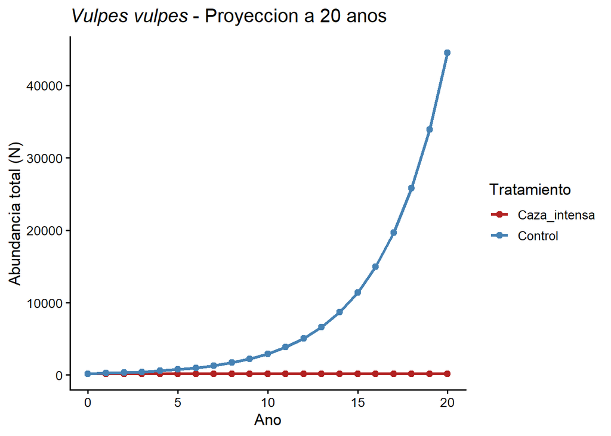

Abundancia total proyectada a 20 años para ambas poblaciones de Vulpes vulpes.

```r
N0_v    <- c(100, 50, 20, 10)
years_v <- 20

Nh <- proyectar(vulpes_haunt, N0_v, years_v)
Nu <- proyectar(vulpes_unman, N0_v, years_v)

data.frame(
  Ano          = 0:years_v,
  Caza_intensa = colSums(Nh),
  Control      = colSums(Nu)
) %>%
  pivot_longer(cols = -Ano, names_to = "Tratamiento", values_to = "N_total") %>%
  ggplot(aes(x = Ano, y = N_total, color = Tratamiento)) +
  geom_line(linewidth = 1.1) +
  geom_point(size = 2) +
  scale_color_manual(values = c("Caza_intensa" = "firebrick", "Control" = "steelblue")) +
  labs(
    title = expression(italic("Vulpes vulpes") ~ "- Proyeccion a 20 anos"),
    x     = "Ano",
    y     = "Abundancia total (N)"
  ) +
  theme_classic(base_size = 13)
```

### 4. Análisis de elasticidad comparativo

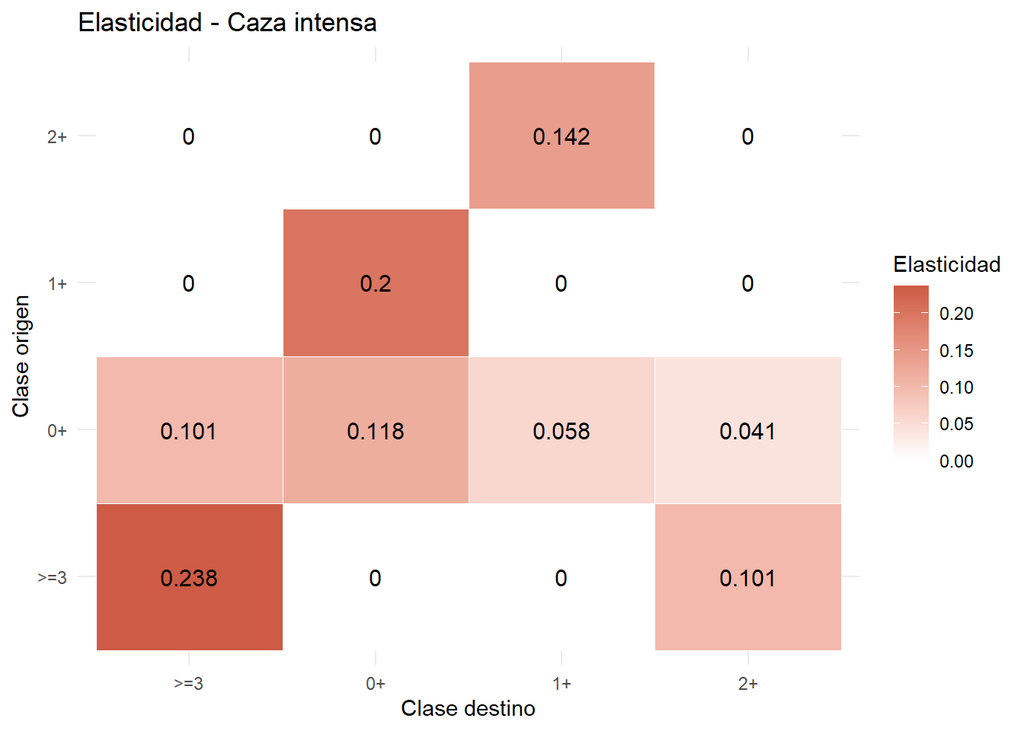

Elasticidades de ambas poblaciones de Vulpes vulpes.

```r
E_haunt <- elas(vulpes_haunt, eval = "max")
E_unman <- elas(vulpes_unman, eval = "max")

plot_elas <- function(E, titulo, clases) {
  as.data.frame(E) %>%
    setNames(clases) %>%
    mutate(Origen = clases) %>%
    pivot_longer(cols = -Origen, names_to = "Destino", values_to = "Elasticidad") %>%
    ggplot(aes(x = Destino, y = Origen, fill = Elasticidad)) +
    geom_tile(color = "white") +
    geom_text(aes(label = round(Elasticidad, 3)), size = 4) +
    scale_fill_gradient(low = "white", high = "coral3") +
    labs(title = titulo, x = "Clase destino", y = "Clase origen") +
    theme_minimal(base_size = 11)
}

print(plot_elas(E_haunt, "Elasticidad - Caza intensa", clases_v))
```

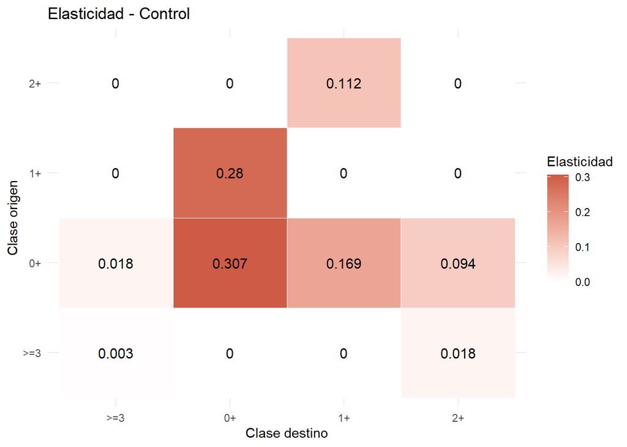

Elasticidades de ambas poblaciones de Vulpes vulpes.

```r
print(plot_elas(E_unman, "Elasticidad - Control",      clases_v))
```

> **Discuta:** ¿Qué parámetro vital (supervivencia vs. fecundidad) domina en cada caso? ¿Qué implicancias tiene esto para el manejo de la especie?

## LTRE: *Life Table Response Experiment*

El **LTRE** descompone la diferencia en $\lambda$ entre dos poblaciones en las contribuciones de cada elemento de la matriz. Para un **LTRE de una vía** (una-vía de referencia = promedio de las dos matrices):

$$\Delta\lambda \approx \sum_{i,j}
\underbrace{\left(a_{ij}^{(haunt)} -
a_{ij}^{(unman)}\right)}_{\text{diferencia}} \cdot
\underbrace{s_{ij}^{(ref)}}_{\text{sensibilidad}}$$

donde $s_{ij}^{(ref)}$ es la sensibilidad calculada en la **matriz de referencia** (promedio de ambas matrices).

```r
A_ref  <- (vulpes_haunt + vulpes_unman) / 2
S_ref  <- sens(A_ref, eval = "max")
C_ltre <- (vulpes_haunt - vulpes_unman) * S_ref

cat("Diferencia observada en lambda (haunt - unman):",
    round(res_haunt$lambda - res_unman$lambda, 6), "\n")
```

```
## Diferencia observada en lambda (haunt - unman): -0.314427
```

```r
cat("Suma de contribuciones LTRE:                  ",
    round(sum(C_ltre), 6), "\n")
```

```
## Suma de contribuciones LTRE:                   -0.334419
```

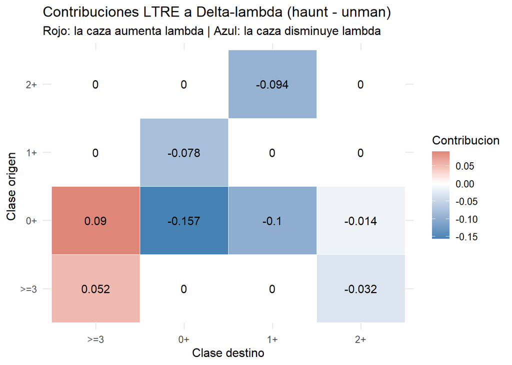

Contribuciones LTRE a la diferencia en lambda entre la población cazada y el control. Rojo: la caza aumenta lambda; azul: la caza disminuye lambda.

```r
as.data.frame(C_ltre) %>%
  setNames(clases_v) %>%
  mutate(Origen = clases_v) %>%
  pivot_longer(cols = -Origen, names_to = "Destino", values_to = "Contribucion") %>%
  ggplot(aes(x = Destino, y = Origen, fill = Contribucion)) +
  geom_tile(color = "white") +
  geom_text(aes(label = round(Contribucion, 3)), size = 4) +
  scale_fill_gradient2(low = "steelblue", mid = "white", high = "firebrick", midpoint = 0) +
  labs(
    title    = "Contribuciones LTRE a Delta-lambda (haunt - unman)",
    subtitle = "Rojo: la caza aumenta lambda | Azul: la caza disminuye lambda",
    x        = "Clase destino",
    y        = "Clase origen"
  ) +
  theme_minimal(base_size = 12)
```

> **Discuta:** Identifique las transiciones con contribuciones positivas y negativas. ¿Qué efectos demográficos de la caza explican cada contribución? ¿Son los resultados coherentes con lo que se espera de una respuesta compensatoria?

# Bonus: *Gorilla gorilla*

Se proporciona una tabla de vida para gorila (*Gorilla gorilla*) en el archivo `Gorilla_lt.xlsx`. Su tarea es:

1. Cargar la tabla de vida e inspeccionarla.
2. Calcular $R_0$, $T$ y $r$.
3. Construir la Matriz de Leslie usando `leslie_from_table()`.
4. Realizar el eigenanálisis completo: $\lambda_1$, $\mathbf{w}$, $\mathbf{v}$ y $\rho$.
5. Calcular sensibilidad y elasticidad. ¿Qué parámetro vital domina?
6. Compare los resultados con los de *Vulpes vulpes*. ¿Qué diferencias esperaría dado que el gorila tiene una historia de vida mucho más lenta (*slow life history*)?

```r
gorilla <- read_xlsx("Gorilla_lt.xlsx", sheet = "Hoja1")
kable(gorilla, caption = "Tabla de vida de Gorilla gorilla")
```

Tabla de vida de Gorilla gorilla

| x | d.x | p.x | c.x | t.x | N.x | q.x | N.q.x | m.x | m.x.CI.low | m.x.CI.up | N.f.x | N.o.x | e.x | e.x.CL.up | e.x.CL.low | l.x | l.x.CI.low | l.x.CI.up | w | w.CL.low | w.CL.up | v | v.CL.low |
| --- | --- | --- | --- | --- | --- | --- | --- | --- | --- | --- | --- | --- | --- | --- | --- | --- | --- | --- | --- | --- | --- | --- | --- |
| 0 | 23 | 0 | 0 | 110 | 110 | 0.209 | 110 | 0.0000000 | 0.0000000 | 0.0215293 | 87.527036 | 0.000000 | 21.013131 | 17.876805 | 24.320284 | 1.0000000 | 0.9509761 | 1.0000000 | 0.0757829 | 0.0690242 | 0.0823581 | 1.0000000 | 1.0000000 |
| 1 | 10 | 0 | 1 | 2 | 89 | 0.113 | 89 | 0.0000000 | 0.0000000 | 0.0245570 | 76.263518 | 0.000000 | 25.301051 | 21.986801 | 28.627676 | 0.7909091 | 0.7418806 | 0.8399376 | 0.0580553 | 0.0519299 | 0.0639760 | 1.3053578 | 1.1995602 |
| 2 | 3 | 0 | 5 | 0 | 78 | 0.040 | 76 | 0.0000000 | 0.0000000 | 0.0269706 | 69.859001 | 0.000000 | 27.396900 | 24.281164 | 30.566179 | 0.7015408 | 0.6550544 | 0.7480273 | 0.0498723 | 0.0444308 | 0.0551053 | 1.5195395 | 1.3664136 |
| 3 | 3 | 0 | 2 | 1 | 71 | 0.043 | 70 | 0.0000000 | 0.0000000 | 0.0294517 | 63.845996 | 0.000000 | 27.496771 | 24.450265 | 30.502578 | 0.6736650 | 0.6258847 | 0.7214454 | 0.0463686 | 0.0415019 | 0.0510579 | 1.6343565 | 1.4698664 |
| 4 | 0 | 0 | 4 | 1 | 67 | 0.000 | 65 | 0.0000000 | 0.0000000 | 0.0303834 | 61.101301 | 0.000000 | 27.687326 | 24.851351 | 30.567885 | 0.6447937 | 0.5990611 | 0.6905263 | 0.0429764 | 0.0387307 | 0.0470856 | 1.7633597 | 1.5783792 |
| 5 | 0 | 0 | 4 | 4 | 67 | 0.000 | 65 | 0.0000000 | 0.0000000 | 0.0308717 | 60.381246 | 0.000000 | 26.687326 | 23.851351 | 29.567885 | 0.6447937 | 0.5990611 | 0.6905263 | 0.0416221 | 0.0378195 | 0.0452673 | 1.8207359 | 1.6330938 |
| 6 | 0 | 0 | 1 | 2 | 65 | 0.000 | 65 | 0.0000000 | 0.0000000 | 0.0313759 | 59.634497 | 0.000000 | 25.687326 | 22.851351 | 28.567885 | 0.6447937 | 0.5990611 | 0.6905263 | 0.0403105 | 0.0369090 | 0.0435724 | 1.8799790 | 1.6898925 |
| 7 | 1 | 0 | 8 | 4 | 68 | 0.016 | 64 | 0.0000000 | 0.0000000 | 0.0318969 | 58.262834 | 0.000000 | 24.687326 | 21.851351 | 27.567885 | 0.6447937 | 0.5979473 | 0.6916401 | 0.0390402 | 0.0360100 | 0.0419311 | 1.9411498 | 1.7488213 |
| 8 | 2 | 0 | 1 | 5 | 64 | 0.031 | 64 | 0.1192750 | 0.0491098 | 0.2125212 | 57.043806 | 13.607803 | 24.072486 | 21.278966 | 26.867293 | 0.6347188 | 0.5864191 | 0.6830185 | 0.0372050 | 0.0344832 | 0.0396814 | 2.0369014 | 1.8368976 |
| 9 | 0 | 1 | 4 | 3 | 64 | 0.016 | 62 | 0.1793431 | 0.0956932 | 0.2871489 | 59.142368 | 21.213552 | 23.810615 | 21.218836 | 26.449965 | 0.6147276 | 0.5668931 | 0.6625622 | 0.0349156 | 0.0324008 | 0.0372385 | 2.0473716 | 1.8354836 |
| 10 | 0 | 1 | 6 | 2 | 61 | 0.017 | 58 | 0.1580771 | 0.0792310 | 0.2730268 | 53.136893 | 16.799452 | 23.181519 | 20.654163 | 25.770564 | 0.6048127 | 0.5565885 | 0.6530369 | 0.0332742 | 0.0310082 | 0.0354065 | 1.9661035 | 1.7441008 |
| 11 | 0 | 0 | 3 | 2 | 56 | 0.000 | 55 | 0.0575468 | 0.0104733 | 0.1350687 | 50.127310 | 5.769336 | 22.565127 | 20.122222 | 25.161844 | 0.5943849 | 0.5469921 | 0.6417776 | 0.0316778 | 0.0295881 | 0.0336114 | 1.9043738 | 1.6736041 |
| 12 | 0 | 0 | 1 | 0 | 53 | 0.000 | 53 | 0.1173310 | 0.0463316 | 0.2278011 | 47.001369 | 11.029432 | 21.565127 | 19.122222 | 24.161844 | 0.5943849 | 0.5469921 | 0.6417776 | 0.0306796 | 0.0288178 | 0.0324438 | 1.9087915 | 1.6720577 |
| 13 | 0 | 0 | 4 | 0 | 52 | 0.000 | 50 | 0.2000272 | 0.1108471 | 0.3425904 | 45.346338 | 18.140999 | 20.565127 | 18.122222 | 23.161844 | 0.5943849 | 0.5469921 | 0.6417776 | 0.0297128 | 0.0280148 | 0.0313810 | 1.8535688 | 1.6104053 |
| 14 | 0 | 1 | 3 | 1 | 49 | 0.021 | 48 | 0.0976756 | 0.0375534 | 0.2226399 | 42.521561 | 8.306639 | 19.565127 | 17.122222 | 22.161844 | 0.5943849 | 0.5453336 | 0.6434361 | 0.0287765 | 0.0271361 | 0.0304025 | 1.7138531 | 1.4690022 |
| 15 | 1 | 0 | 2 | 2 | 47 | 0.022 | 46 | 0.0359965 | 0.0039211 | 0.1272103 | 41.670773 | 3.000000 | 18.963357 | 16.548002 | 21.452602 | 0.5818715 | 0.5321790 | 0.6315640 | 0.0272844 | 0.0256098 | 0.0289028 | 1.7078068 | 1.4532315 |
| 16 | 1 | 0 | 0 | 4 | 48 | 0.021 | 48 | 0.1455252 | 0.0696819 | 0.2878705 | 41.229979 | 12.000000 | 18.367441 | 15.981245 | 20.767879 | 0.5692221 | 0.5191544 | 0.6192898 | 0.0258432 | 0.0241784 | 0.0275199 | 1.7662362 | 1.5062334 |
| 17 | 0 | 0 | 6 | 0 | 47 | 0.000 | 44 | 0.1917351 | 0.0940307 | 0.3391111 | 38.111567 | 14.614648 | 17.739980 | 15.462923 | 20.115902 | 0.5573633 | 0.5083387 | 0.6063879 | 0.0245032 | 0.0228261 | 0.0262091 | 1.7141785 | 1.4515186 |
| 18 | 1 | 0 | 1 | 0 | 41 | 0.025 | 41 | 0.1188466 | 0.0430101 | 0.2499696 | 37.123888 | 8.824093 | 16.739980 | 14.462923 | 19.115902 | 0.5573633 | 0.5063966 | 0.6083300 | 0.0237311 | 0.0220574 | 0.0255067 | 1.5782194 | 1.3094859 |
| 19 | 1 | 0 | 3 | 0 | 39 | 0.027 | 38 | 0.1741367 | 0.0826581 | 0.3319034 | 35.123888 | 12.232717 | 16.143570 | 13.951404 | 18.463746 | 0.5436013 | 0.4917669 | 0.5954356 | 0.0224087 | 0.0206530 | 0.0241884 | 1.5494615 | 1.2822595 |
| 20 | 0 | 0 | 2 | 1 | 36 | 0.000 | 35 | 0.2088352 | 0.1096513 | 0.3843057 | 33.412731 | 13.955510 | 15.563792 | 13.501122 | 17.805802 | 0.5291052 | 0.4786531 | 0.5795574 | 0.0211165 | 0.0192688 | 0.0229501 | 1.4653044 | 1.1920383 |
| 21 | 0 | 1 | 2 | 0 | 34 | 0.030 | 33 | 0.0485135 | 0.0055190 | 0.1695577 | 30.919233 | 3.000000 | 14.563792 | 12.501122 | 16.805802 | 0.5291052 | 0.4760909 | 0.5821196 | 0.0204511 | 0.0185707 | 0.0223876 | 1.3041473 | 1.0317388 |
| 22 | 0 | 0 | 1 | 0 | 31 | 0.000 | 31 | 0.1186510 | 0.0360533 | 0.2680892 | 29.498289 | 7.000000 | 13.983291 | 12.040291 | 16.130299 | 0.5130717 | 0.4616639 | 0.5644796 | 0.0192124 | 0.0172410 | 0.0213002 | 1.3382146 | 1.0557769 |
| 23 | 0 | 0 | 2 | 0 | 30 | 0.000 | 29 | 0.2096178 | 0.1055787 | 0.4037547 | 28.530459 | 11.960986 | 12.983291 | 11.040291 | 15.130299 | 0.5130717 | 0.4616639 | 0.5644796 | 0.0186070 | 0.0165989 | 0.0207751 | 1.2631064 | 0.9790054 |
| 24 | 1 | 0 | 1 | 1 | 29 | 0.035 | 29 | 0.1705138 | 0.0631787 | 0.3422105 | 26.390828 | 9.000000 | 11.983291 | 10.040291 | 14.130299 | 0.5130717 | 0.4584948 | 0.5676487 | 0.0180206 | 0.0159717 | 0.0202567 | 1.0945876 | 0.8226382 |
| 25 | 0 | 0 | 1 | 1 | 28 | 0.000 | 28 | 0.0611507 | 0.0067686 | 0.1997608 | 25.268309 | 3.090349 | 11.381648 | 9.513231 | 13.457261 | 0.4950692 | 0.4424072 | 0.5477312 | 0.0168419 | 0.0146453 | 0.0192175 | 0.9944969 | 0.7290032 |
| 26 | 0 | 0 | 1 | 1 | 28 | 0.000 | 28 | 0.1863393 | 0.0879997 | 0.3870966 | 26.500342 | 9.876112 | 10.381648 | 8.513231 | 12.457261 | 0.4950692 | 0.4424072 | 0.5477312 | 0.0163112 | 0.0141195 | 0.0187487 | 0.9657051 | 0.7020909 |
| 27 | 0 | 0 | 0 | 1 | 28 | 0.000 | 28 | 0.1839772 | 0.0843918 | 0.3746710 | 27.177276 | 10.000000 | 9.381648 | 7.513231 | 11.457261 | 0.4950692 | 0.4424072 | 0.5477312 | 0.0157972 | 0.0135823 | 0.0183006 | 0.8107879 | 0.5569835 |
| 28 | 1 | 1 | 3 | 0 | 28 | 0.075 | 27 | 0.1290218 | 0.0465825 | 0.3285590 | 23.251882 | 6.000000 | 8.381648 | 6.513231 | 10.457261 | 0.4950692 | 0.4356698 | 0.5544686 | 0.0152994 | 0.0130586 | 0.0178687 | 0.6531921 | 0.4118709 |
| 29 | 1 | 1 | 1 | 1 | 24 | 0.085 | 24 | 0.1093768 | 0.0321251 | 0.3377529 | 18.285421 | 4.000000 | 7.980160 | 6.092893 | 10.036333 | 0.4577055 | 0.3956968 | 0.5197143 | 0.0137059 | 0.0113121 | 0.0163541 | 0.5896474 | 0.3521472 |
| 30 | 1 | 0 | 0 | 0 | 21 | 0.048 | 21 | 0.0876762 | 0.0113677 | 0.2938024 | 16.995209 | 2.980151 | 7.628591 | 5.772072 | 9.686336 | 0.4187519 | 0.3584529 | 0.4790508 | 0.0121457 | 0.0096933 | 0.0150003 | 0.5458542 | 0.3082457 |
| 31 | 2 | 0 | 0 | 0 | 20 | 0.100 | 20 | 0.1015100 | 0.0133621 | 0.3280232 | 14.776865 | 3.000000 | 6.962805 | 5.088910 | 8.981244 | 0.3988113 | 0.3341465 | 0.4634761 | 0.0111984 | 0.0087306 | 0.0141239 | 0.4999360 | 0.2604714 |
| 32 | 1 | 1 | 1 | 0 | 18 | 0.114 | 18 | 0.0697308 | 0.0133621 | 0.3280232 | 14.340862 | 2.000000 | 6.625339 | 4.827908 | 8.637267 | 0.3589302 | 0.2930746 | 0.4247857 | 0.0097609 | 0.0072376 | 0.0126435 | 0.4607699 | 0.2210957 |
| 33 | 2 | 0 | 2 | 0 | 15 | 0.143 | 14 | 0.1344429 | 0.0204263 | 0.4271740 | 10.075291 | 2.709103 | 6.349141 | 4.580028 | 8.300801 | 0.3179096 | 0.2500460 | 0.3857731 | 0.0083757 | 0.0058960 | 0.0112750 | 0.4582749 | 0.1973963 |
| 34 | 1 | 0 | 0 | 0 | 11 | 0.091 | 11 | 0.1290398 | 0.0275038 | 0.5026139 | 8.746749 | 2.257358 | 6.241705 | 4.584416 | 8.067879 | 0.2724939 | 0.2087865 | 0.3362013 | 0.0069517 | 0.0044716 | 0.0098354 | 0.3952664 | 0.1419963 |
| 35 | 0 | 0 | 0 | 0 | 10 | 0.000 | 10 | 0.0555556 | 0.0004398 | 0.3609630 | 9.000000 | 1.000000 | 5.766452 | 4.269683 | 7.444444 | 0.2477217 | 0.1898059 | 0.3056376 | 0.0061200 | 0.0037171 | 0.0089343 | 0.3070273 | 0.0852741 |
| 36 | 1 | 0 | 0 | 0 | 10 | 0.100 | 10 | 0.0000000 | 0.0000000 | 0.1873657 | 8.851472 | 0.000000 | 4.766452 | 3.269683 | 6.444444 | 0.2477217 | 0.1841915 | 0.3112520 | 0.0059271 | 0.0035998 | 0.0086960 | 0.2614618 | 0.0539379 |
| 37 | 2 | 0 | 0 | 0 | 9 | 0.222 | 9 | 0.2155715 | 0.0412829 | 0.6091167 | 6.958248 | 3.000000 | 4.184947 | 2.587302 | 5.857143 | 0.2229496 | 0.1533276 | 0.2925715 | 0.0051663 | 0.0029633 | 0.0079003 | 0.2999658 | 0.0686416 |
| 38 | 2 | 0 | 0 | 0 | 7 | 0.286 | 7 | 0.0000000 | 0.0000000 | 0.2641729 | 5.470226 | 0.000000 | 4.093762 | 2.714286 | 5.500000 | 0.1734052 | 0.1052105 | 0.2415999 | 0.0038927 | 0.0018922 | 0.0064979 | 0.1210213 | 0.0000000 |
| 39 | 0 | 0 | 0 | 0 | 5 | 0.000 | 5 | 0.1000000 | 0.0017100 | 0.5639827 | 5.000000 | 1.000000 | 4.333000 | 4.000000 | 4.666667 | 0.1238609 | 0.0751504 | 0.1725714 | 0.0026918 | 0.0010173 | 0.0051535 | 0.1750127 | 0.0000000 |
| 40 | 0 | 0 | 0 | 1 | 6 | 0.000 | 6 | 0.0833333 | 0.0010634 | 0.4952471 | 6.000000 | 1.000000 | 3.333000 | 3.000000 | 3.666667 | 0.1238609 | 0.0751504 | 0.1725714 | 0.0026070 | 0.0009797 | 0.0049992 | 0.0807073 | 0.0000000 |
| 41 | 0 | 0 | 0 | 0 | 6 | 0.000 | 6 | 0.0000000 | 0.0000000 | 0.2641729 | 6.000000 | 0.000000 | 2.333000 | 2.000000 | 2.666667 | 0.1238609 | 0.0751504 | 0.1725714 | 0.0025249 | 0.0009430 | 0.0048659 | 0.0000000 | 0.0000000 |
| 42 | 4 | 0 | 0 | 0 | 6 | 0.667 | 6 | 0.0000000 | 0.0000000 | 0.3624868 | 3.514032 | 0.000000 | 1.333000 | 1.000000 | 1.666667 | 0.1238609 | 0.0373360 | 0.2103857 | 0.0024453 | 0.0009086 | 0.0047506 | 0.0000000 | 0.0000000 |
| 43 | 2 | 0 | 0 | 0 | 2 | 1.000 | 2 | 0.0000000 | 0.0000000 | 0.5692585 | 1.664613 | 0.000000 | 1.000000 | 1.000000 | 1.000000 | 0.0412870 | 0.0000000 | 0.0916502 | 0.0007886 | 0.0000000 | 0.0022679 | 0.0000000 | 0.0000000 |
| 44 | 0 | 0 | 0 | 0 | 0 | 0.000 | 0 | 0.0000000 | 0.0000000 | 0.0000000 | 0.000000 | 0.000000 | 0.000000 | 0.000000 | 0.000000 | 0.0000000 | 0.0000000 | 0.0000000 | 0.0000000 | 0.0000000 | 0.0000000 | 0.0000000 | 0.0000000 |

```r
# Su analisis aqui:
```